# tipos_de_interes

Garcia Giron A.

09/8/2020

## Visualización de datos

Head y Tail

```
##            X DEPO.1M DEPO.3M DEPO.6M DEPO.12M IRS.2Y IRS.3Y IRS.4Y IRS.5Y
## 1 02/01/1995   6.000   6.500   7.000    7.750  8.170   8.24   8.25   8.22
## 2 03/01/1995   5.938   6.500   7.000    7.813  8.220   8.28   8.29   8.29
## 3 04/01/1995   5.938   6.500   7.000    7.813  8.130   8.20   8.23   8.24
## 4 05/01/1995   5.898   6.438   6.938    7.688  8.145   8.22   8.26   8.27
## 5 06/01/1995   5.875   6.438   6.938    7.688  8.070   8.20   8.25   8.27
## 6 09/01/1995   5.875   6.375   6.875    7.688  8.135   8.25   8.29   8.31
##   IRS.7Y IRS.10Y
## 1   8.24    8.25
## 2   8.30    8.31
## 3   8.26    8.28
## 4   8.29    8.30
## 5   8.29    8.29
## 6   8.33    8.34
```

```
##              X DEPO.1M DEPO.3M DEPO.6M DEPO.12M IRS.2Y IRS.3Y IRS.4Y IRS.5Y
## 973 23/09/1998      NA   5.500   5.406    5.254  5.105  5.145  5.215  5.295
## 974 24/09/1998      NA   5.438   5.344    5.156  5.025  5.075  5.155  5.245
## 975 25/09/1998      NA   5.313   5.250    5.063  4.935  4.975  5.065  5.145
## 976 28/09/1998      NA   5.313   5.250    5.063  4.925  4.965  5.045  5.125
## 977 29/09/1998      NA   5.313   5.250    5.063  4.945  4.985  5.075  5.155
## 978 30/09/1998      NA   5.313   5.246    5.063  4.815  4.855  4.925  5.005
##     IRS.7Y IRS.10Y
## 973  5.405   5.555
## 974  5.355   5.495
## 975  5.245   5.385
## 976  5.235   5.375
## 977  5.255   5.395
## 978  5.115   5.245
```

## Análisis exploratorio de los datos

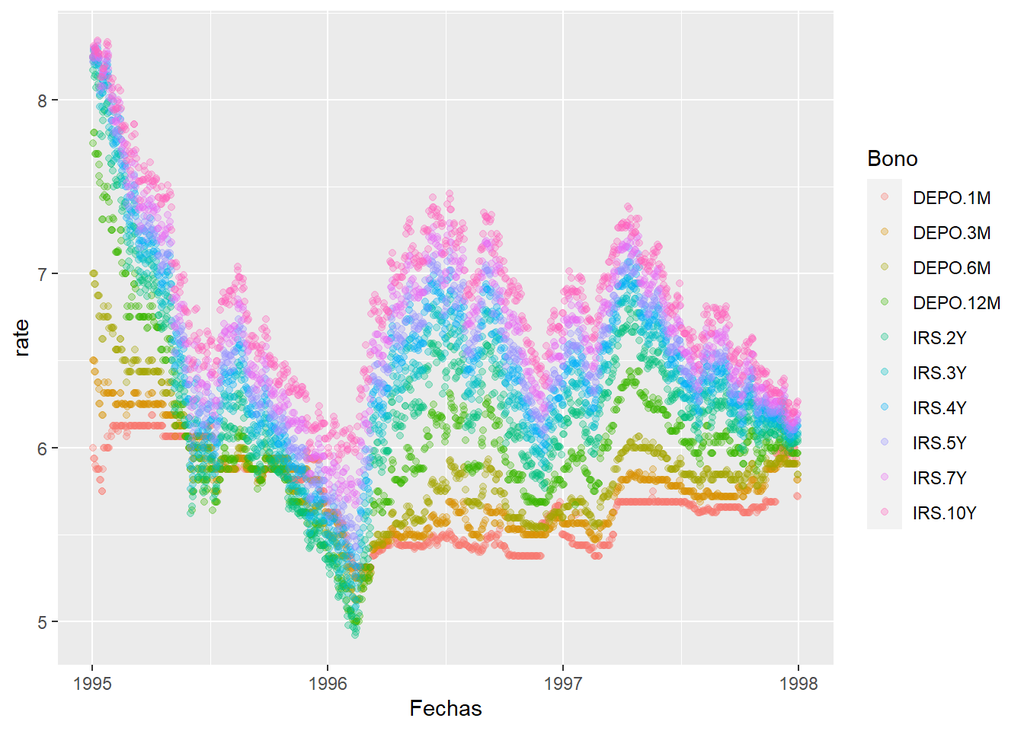

Realizamos un summary de las variables de nuestro dataset

```
##          Min  Q1 Med Mean  SD  Q3 Max
## DEPO.1M  5.3 5.4 5.7  5.7  NA 5.9 6.2
## DEPO.3M  5.2 5.6 5.7  5.7 0.2 5.9 6.5
## DEPO.6M  5.1 5.7 5.8  5.8 0.3 5.9 7.0
## DEPO.12M 5.0 5.8 5.9  6.0 0.4 6.1 7.8
## IRS.2Y   4.9 5.9 6.1  6.1 0.5 6.3 8.2
## IRS.3Y   5.1 6.0 6.2  6.3 0.5 6.5 8.3
## IRS.4Y   5.3 6.0 6.3  6.4 0.5 6.6 8.3
## IRS.5Y   5.4 6.1 6.4  6.5 0.5 6.7 8.3
```

**Análisis de la matriz de correlación**

Nos indica el grado de correlacion entre las variables

```
##          DEPO.1M DEPO.3M DEPO.6M DEPO.12M IRS.2Y IRS.3Y IRS.4Y IRS.5Y
## DEPO.1M     1.00    0.92    0.74     0.51   0.35   0.31   0.28   0.26
## DEPO.3M     0.92    1.00    0.93     0.76   0.63   0.59   0.56   0.53
## DEPO.6M     0.74    0.93    1.00     0.94   0.86   0.82   0.80   0.77
## DEPO.12M    0.51    0.76    0.94     1.00   0.97   0.95   0.93   0.91
## IRS.2Y      0.35    0.63    0.86     0.97   1.00   0.99   0.98   0.97
## IRS.3Y      0.31    0.59    0.82     0.95   0.99   1.00   1.00   0.99
## IRS.4Y      0.28    0.56    0.80     0.93   0.98   1.00   1.00   1.00
## IRS.5Y      0.26    0.53    0.77     0.91   0.97   0.99   1.00   1.00
##
## n
##          DEPO.1M DEPO.3M DEPO.6M DEPO.12M IRS.2Y IRS.3Y IRS.4Y IRS.5Y
## DEPO.1M      783     783     783      783    783    783    783    783
## DEPO.3M      783     949     949      949    949    949    949    949
## DEPO.6M      783     949     949      949    949    949    949    949
## DEPO.12M     783     949     949      949    949    949    949    949
## IRS.2Y       783     949     949      949    949    949    949    949
## IRS.3Y       783     949     949      949    949    949    949    949
## IRS.4Y       783     949     949      949    949    949    949    949
## IRS.5Y       783     949     949      949    949    949    949    949
##
## P
##          DEPO.1M DEPO.3M DEPO.6M DEPO.12M IRS.2Y IRS.3Y IRS.4Y IRS.5Y
## DEPO.1M           0       0       0        0      0      0      0
## DEPO.3M   0               0       0        0      0      0      0
## DEPO.6M   0       0               0        0      0      0      0
## DEPO.12M  0       0       0                0      0      0      0
## IRS.2Y    0       0       0       0               0      0      0
## IRS.3Y    0       0       0       0        0             0      0
## IRS.4Y    0       0       0       0        0      0             0
## IRS.5Y    0       0       0       0        0      0      0
```

El grafico de correlaciones que presentamos en la parte inferior de este texto nos muestra que cada titulo esta bastante correlacionado con el del periodo inmediatamente posterior e incluso, a partir de un año, suelen presentar correlaciones altas entre ellos

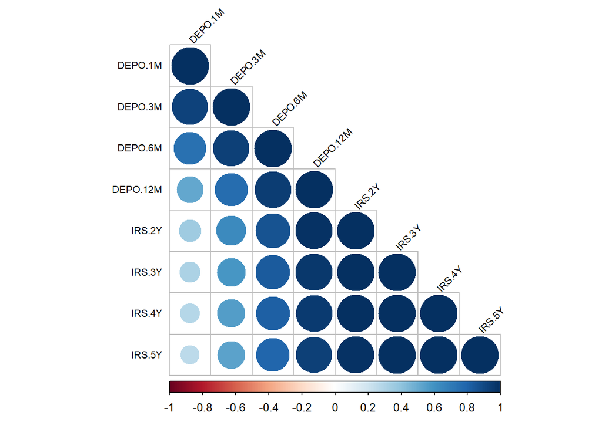

Para visualizar clusters utilizamos el correlograma siguiente.

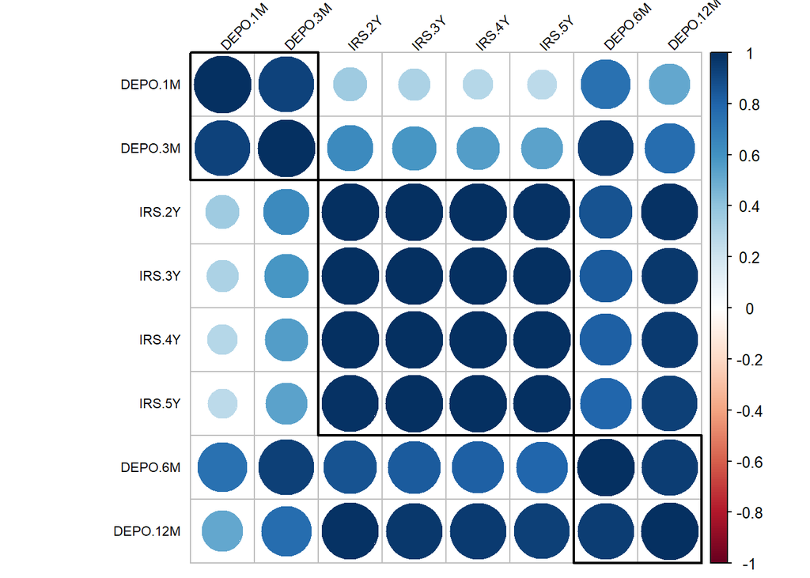

En el cluster anterior vemos claramente diferenciados tres grupos corto plazo 1my 3m. medio plazo 6m y 12m . largo plazo 2y, 3y, 4y, 5y.

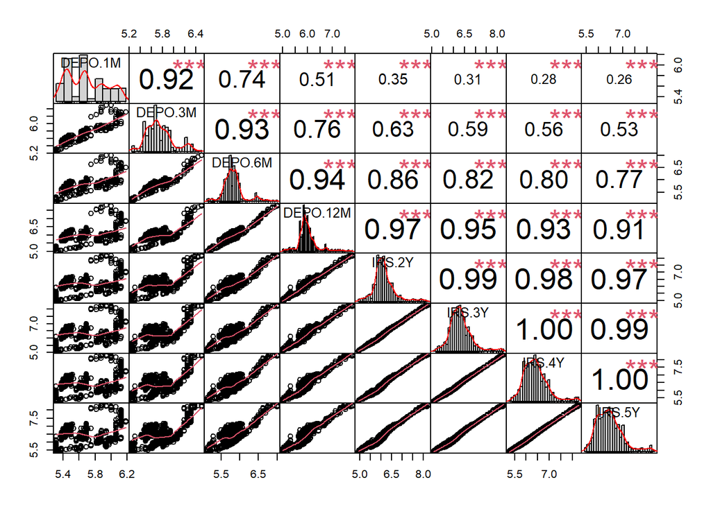

Sustancialmente bajo vamos a hallar el determinante de la matriz de correlaciones. entendemos debido a su cuantia que hay fuerte asociacion entre las variables

```
## [1] 5.5021e-12
```

p de esfericidad de Bartlett nos va a permitir verificar el dataset, es decir, que sea idoneo para reducir su dimension

```
## R was not square, finding R from data
```

```
## $chisq
## [1] 31782.42
##
## $p.value
## [1] 0
##
## $df
## [1] 28
```

```
## $KMO
## [1] 0.83799
##
## $MSA
##              MSA
## DEPO.1M  0.79261
## DEPO.3M  0.78144
## DEPO.6M  0.84063
## DEPO.12M 0.91650
## IRS.2Y   0.84798
## IRS.3Y   0.81641
## IRS.4Y   0.81881
## IRS.5Y   0.85404
##
## $Bartlett
## [1] 26624
##
## $Communalities
##          Initial Communalities Final Extraction
## DEPO.1M                0.94860          0.91222
## DEPO.3M                0.98923          1.01486
## DEPO.6M                0.99477          0.98689
## DEPO.12M               0.99431          0.98145
## IRS.2Y                 0.99957          0.99685
## IRS.3Y                 0.99986          1.00106
## IRS.4Y                 0.99985          0.99612
## IRS.5Y                 0.99955          0.98408
##
## $Factor.Loadings
##             [,1]      [,2]
## DEPO.1M  0.55771  0.775357
## DEPO.3M  0.79742  0.615613
## DEPO.6M  0.95493  0.273862
## DEPO.12M 0.98948 -0.048795
## IRS.2Y   0.96922 -0.239718
## IRS.3Y   0.95662 -0.293141
## IRS.4Y   0.94430 -0.323143
## IRS.5Y   0.93110 -0.342238
##
## $RMS
## [1] 0.0042233
```

Indice KMO de Kaiser-Meyer-Olkin. este contrasta si las correlaciones entre las variables son suficientemente pequeñas, el KMO varia entre 0 y 1 unos valores proximos a cero indican que el analisis puede no ser una buena idea

```
## [1] 0.83799
```

Resultado de 0.83, porseguimos con el estudio ya que el valor se aproxima a uno.

Matriz de Adecuación de la Muestra (MSA) Ya que los coef son altos mantenemos la misma conclusión que anteriormente.

```
##              MSA
## DEPO.1M  0.79261
## DEPO.3M  0.78144
## DEPO.6M  0.84063
## DEPO.12M 0.91650
## IRS.2Y   0.84798
## IRS.3Y   0.81641
## IRS.4Y   0.81881
## IRS.5Y   0.85404
```

Hacemos honor al nombre de la asignatura reduciendo la dimension, con dos componentes tenemos un 98,63% de la varianza explicada, por ende, continuamos con estos dos.

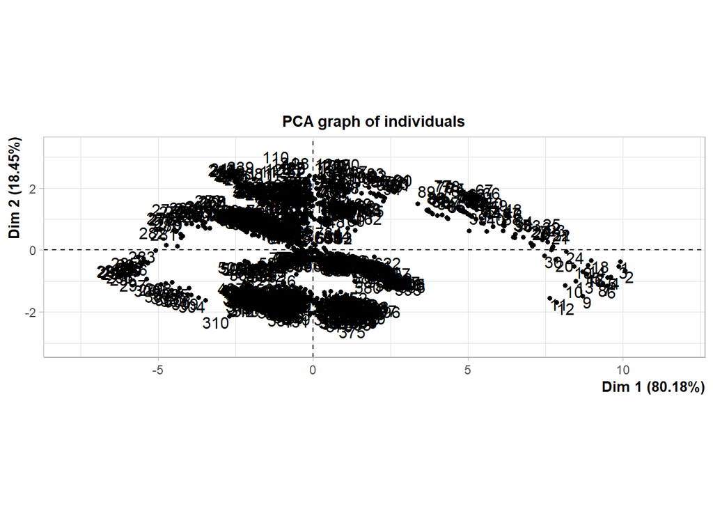

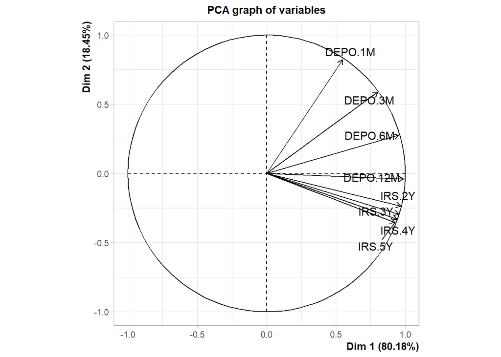

```
##        eigenvalue percentage of variance cumulative percentage of variance
## comp 1       6.41                  80.18                             80.18
## comp 2       1.48                  18.45                             98.63
## comp 3       0.08                   0.98                             99.61
## comp 4       0.02                   0.29                             99.90
## comp 5       0.00                   0.06                             99.96
## comp 6       0.00                   0.04                            100.00
## comp 7       0.00                   0.00                            100.00
## comp 8       0.00                   0.00                            100.00
```

Gráfico de sedimentación o scree plot.

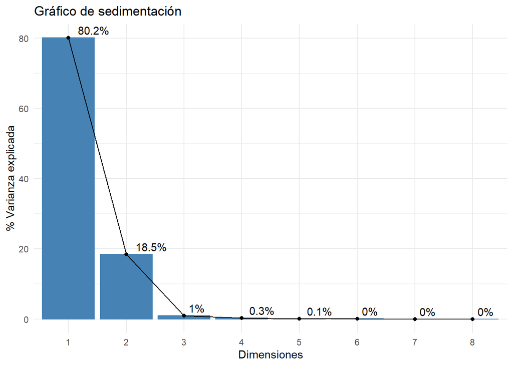

En el grafico se ve que la aportacion de los dos primeros componentes es sustancial

## rotación Varimax

“Con la Rotación Varimax de todos los factores se obtiene un mejor resultado, ya que al hacer una rotación ortogonal, tiende a asimilar cada variable con un eje. Esto facilita el significado de la interpretación de los componentes seleccionados” (estamatica, 2020)

```
## Factor Analysis using method =  minres
## Call: fa(r = tiposdolar.act, nfactors = 2, rotate = "varimax", fm = "minres")
## Standardized loadings (pattern matrix) based upon correlation matrix
##           MR1  MR2   h2      u2 com
## DEPO.1M  0.08 0.95 0.92  0.0837 1.0
## DEPO.3M  0.37 0.93 1.00 -0.0036 1.3
## DEPO.6M  0.67 0.73 0.98  0.0175 2.0
## DEPO.12M 0.86 0.48 0.97  0.0310 1.6
## IRS.2Y   0.95 0.30 1.00  0.0048 1.2
## IRS.3Y   0.97 0.24 1.00 -0.0001 1.1
## IRS.4Y   0.97 0.21 0.99  0.0076 1.1
## IRS.5Y   0.97 0.18 0.97  0.0307 1.1
##
##                        MR1  MR2
## SS loadings           5.07 2.76
## Proportion Var        0.63 0.34
## Cumulative Var        0.63 0.98
## Proportion Explained  0.65 0.35
## Cumulative Proportion 0.65 1.00
##
## Mean item complexity =  1.3
## Test of the hypothesis that 2 factors are sufficient.
##
## The degrees of freedom for the null model are  28  and the objective function was  33.65 with Chi Square of  31782
## The degrees of freedom for the model are 13  and the objective function was  9.23
##
## The root mean square of the residuals (RMSR) is  0.01
## The df corrected root mean square of the residuals is  0.01
##
## The harmonic number of observations is  904 with the empirical chi square  3.45  with prob <  1
## The total number of observations was  949  with Likelihood Chi Square =  8705.1  with prob <  0
##
## Tucker Lewis Index of factoring reliability =  0.41
## RMSEA index =  0.839  and the 90 % confidence intervals are  0.825 0.855
## BIC =  8616
## Fit based upon off diagonal values = 1
```

Prediccion

```
##     DEPO.1M DEPO.3M DEPO.6M DEPO.12M IRS.2Y IRS.3Y IRS.4Y IRS.5Y IRS.7Y IRS.10Y
## 1     6.000   6.500   7.000    7.750  8.170  8.240  8.250  8.220  8.240   8.250
## 2     5.938   6.500   7.000    7.813  8.220  8.280  8.290  8.290  8.300   8.310
## 3     5.938   6.500   7.000    7.813  8.130  8.200  8.230  8.240  8.260   8.280
## 4     5.898   6.438   6.938    7.688  8.145  8.220  8.260  8.270  8.290   8.300
## 5     5.875   6.438   6.938    7.688  8.070  8.200  8.250  8.270  8.290   8.290
## 6     5.875   6.375   6.875    7.688  8.135  8.250  8.290  8.310  8.330   8.340
## 7     5.875   6.375   6.875    7.688  8.090  8.210  8.250  8.250  8.260   8.270
## 8     5.875   6.336   6.875    7.625  8.070  8.200  8.230  8.240  8.250   8.270
## 9     5.813   6.250   6.758    7.563  8.020  8.150  8.190  8.220  8.240   8.260
## 10    5.813   6.250   6.750    7.523  7.800  7.960  8.030  8.050  8.080   8.130
## 11    5.750   6.188   6.625    7.313  7.790  7.960  8.040  8.070  8.080   8.130
## 12    5.750   6.188   6.625    7.313  7.880  8.040  8.110  8.130  8.150   8.180
## 13    5.875   6.313   6.750    7.438  7.930  8.060  8.110  8.140  8.160   8.180
## 14    6.000   6.375   6.813    7.500  7.940  8.080  8.130  8.160  8.160   8.190
```

[output cut: 741 more lines]

```
##     DEPO.1M DEPO.3M DEPO.6M DEPO.12M IRS.2Y IRS.3Y IRS.4Y IRS.5Y IRS.7Y IRS.10Y
## 756   5.688   5.875   5.887    5.980  6.075  6.135  6.165  6.205  6.245   6.315
## 757   5.688   5.875   5.906    6.000  6.075  6.135  6.165  6.195  6.255   6.315
## 758   5.688   5.875   5.906    6.000  6.075  6.135  6.175  6.205  6.265   6.325
## 759   5.969   5.879   5.906    6.000  6.095  6.155  6.185  6.215  6.265   6.325
## 760   5.969   5.902   5.914    6.012  6.115  6.165  6.195  6.215  6.265   6.315
## 761   5.969   5.906   5.938    6.031  6.115  6.165  6.195  6.225  6.265   6.315
## 762   5.992   5.918   5.938    6.047  6.125  6.175  6.205  6.225  6.265   6.315
## 763   6.000   5.938   5.938    6.047  6.085  6.135  6.165  6.195  6.245   6.295
## 764   6.000   5.938   5.938    6.027  6.055  6.105  6.125  6.155  6.205   6.265
## 765   5.969   5.906   5.906    6.000  6.125  6.165  6.205  6.245  6.305   6.375
## 766   6.000   5.938   5.969    6.094  6.165  6.215  6.255  6.275  6.325   6.385
## 767   6.000   5.938   6.000    6.125  6.165  6.215  6.255  6.285  6.335   6.395
## 768   6.000   5.938   5.969    6.094  6.125  6.175  6.205  6.235  6.295   6.355
## 769   5.980   5.938   5.938    6.063  6.055  6.095  6.125  6.155  6.205   6.265
## 770   5.965   5.906   5.906    6.012  6.025  6.065  6.095  6.125  6.175   6.235
## 771   5.961   5.906   5.906    5.973  6.015  6.055  6.085  6.105  6.155   6.215
## 772   5.961   5.906   5.906    6.000  6.055  6.095  6.115  6.145  6.195   6.255
## 773   5.965   5.906   5.914    6.031  6.055  6.095  6.125  6.155  6.195   6.255
## 774   5.969   5.906   5.906    6.031  6.045  6.075  6.105  6.135  6.185   6.235
## 775   5.969   5.906   5.906    6.000  5.995  6.025  6.045  6.075  6.115   6.165
## 776   5.941   5.906   5.906    5.969  6.025  6.065  6.085  6.105  6.145   6.195
## 777   5.969   5.906   5.906    5.969  6.025  6.055  6.095  6.115  6.145   6.195
## 778   6.000   5.906   5.906    5.969  6.025  6.065  6.095  6.105  6.145   6.205
## 779   6.000   5.906   5.906    5.969  6.025  6.065  6.095  6.105  6.145   6.205
## 780   6.000   5.906   5.906    5.969  6.025  6.065  6.095  6.105  6.145   6.205
## 781   5.938   5.906   5.906    5.969  6.035  6.075  6.115  6.145  6.175   6.235
## 782   5.723   5.813   5.844    5.969  6.035  6.075  6.125  6.155  6.185   6.255
## 783   5.719   5.813   5.844    5.969  6.045  6.085  6.125  6.155  6.195   6.265
```

modelo acp

```
## Data:    X dimension: 755 9
##  Y dimension: 755 1
## Fit method: svdpc
## Number of components considered: 9
## TRAINING: % variance explained
##          1 comps  2 comps  3 comps  4 comps  5 comps  6 comps  7 comps  8 comps
## X          92.22    99.26    99.82    99.93    99.97    99.99   100.00   100.00
## IRS.10Y    93.53    96.63    99.26    99.82    99.82    99.82    99.86    99.86
##          9 comps
## X         100.00
## IRS.10Y    99.86
```

Calculo del error

```
## , , 2 comps
##
##     IRS.10Y
## 756  6.5839
## 757  6.5849
## 758  6.5904
## 759  6.5686
## 760  6.5741
## 761  6.5765
## 762  6.5792
## 763  6.5470
## 764  6.5136
## 765  6.5894
## 766  6.6219
## 767  6.6272
```

[output cut: 16 more lines]

```
##       prediccion
##  [1,]     6.5839 6.315
##  [2,]     6.5849 6.315
##  [3,]     6.5904 6.325
##  [4,]     6.5686 6.325
##  [5,]     6.5741 6.315
##  [6,]     6.5765 6.315
##  [7,]     6.5792 6.315
##  [8,]     6.5470 6.295
##  [9,]     6.5136 6.265
## [10,]     6.5894 6.375
## [11,]     6.6219 6.385
## [12,]     6.6272 6.395
## [13,]     6.5868 6.355
## [14,]     6.5167 6.265
## [15,]     6.4916 6.235
## [16,]     6.4768 6.215
## [17,]     6.5121 6.255
## [18,]     6.5174 6.255
## [19,]     6.5029 6.235
## [20,]     6.4493 6.165
## [21,]     6.4802 6.195
## [22,]     6.4789 6.195
## [23,]     6.4753 6.205
## [24,]     6.4753 6.205
## [25,]     6.4753 6.205
## [26,]     6.5022 6.235
## [27,]     6.5408 6.255
## [28,]     6.5464 6.265
```

```
## [1] 0.068356
```

#El objetivo de esta técnica estadística es reducir el numero de variables con las que vamos a trabajar. quizas esto no sea un problema con el actual dataset pero de cara a mas varibles sintetizarlas y reducir la información con la que trabajamos al máximo perdiendo el mínimo de información nos dara una eficiencia computacional relevante de cara a la optimizacion del analisis.

#Hemos reducido a dos los componentes con éxito.

#Referencias

Apuntes de la asignatura. Rotacion Varimax, estamatematica, 2020. a partir de: https://estamatica.net/analisis-factorial-malaga/